# Assignement Introduction:

#### Objectives:

The major goal of this assignment is to illustrate the power of data integration approaches by processing and extracting insights from large-scale datasets utilizing big data platforms.

#### Agenda:

> Introduction

> Python Module:
> 1. Importing Libraries
> 2. Dataset Selection
> 3. Data Preprocessing
>    - Checking for missing values
>    - Data Cleaning
> 4. Data Integration
>    1. Schema Mapping
>    2. Data Transformation
>    3. Integration
>       - Manual Data Reconciliation
>       - Data Integration: Parallel Computing - DASK
> 5. Evaluation and Analysis
>    - Evaluation
>    - Exploratory Data Analysis
> 6. Supplementary Visualizations
> 7. Documentation

> Conclusion

#### KAGGLE DATASET LINK:

https://www.kaggle.com/datasets/mylesoneill/world-university-rankings

# Introduction

"Nexa University" strives to be globally recognized for academic brilliance in the center of a big city. To do this, the university board strives to comprehend the elements that influence worldwide university rankings. Rather than just looking at metrics, they want to know what makes a university genuinely remarkable. Is it research, faculty excellence, alumni success, or a combination of the three?

They enlist the help of data scientist Patrick Chaccour to solve the riddle. Their objective is to examine massive datasets from numerous rating agencies, each with their own set of criteria. The goal is to discover the spirit of top-ranked schools rather than just integrate data.

# Step 1: Importing Libraries

```python
# Step 2: Data Selection & Analysis
import pandas as pd

# Step 4: Data Integration: Parallel Computing - DASK
import dask.dataframe as dd
from multiprocessing import cpu_count

# Step 5: Evaluation and Analysis
import matplotlib.pyplot as plt
```

# Step 2: Dataset Selection

```python
df_uni_ranking = pd.read_csv('Uni_ranking.csv')

df_uni_ranking.head()
```

|  | world_rank | institution | country | national_rank | quality_of_education | alumni_employment | quality_of_faculty | publications | influence | citations | broad_impact | patents | score | year |
| --- | --- | --- | --- | --- | --- | --- | --- | --- | --- | --- | --- | --- | --- | --- |
| 0 | 1 | Harvard University | USA | 1 | 7 | 9 | 1 | 1 | 1 | 1 | NaN | 5 | 100.00 | 2012 |
| 1 | 2 | Massachusetts Institute of Technology | USA | 2 | 9 | 17 | 3 | 12 | 4 | 4 | NaN | 1 | 91.67 | 2012 |
| 2 | 3 | Stanford University | USA | 3 | 17 | 11 | 5 | 4 | 2 | 2 | NaN | 15 | 89.50 | 2012 |
| 3 | 4 | University of Cambridge | United Kingdom | 1 | 10 | 24 | 4 | 16 | 16 | 11 | NaN | 50 | 86.17 | 2012 |
| 4 | 5 | California Institute of Technology | USA | 4 | 2 | 29 | 7 | 37 | 22 | 22 | NaN | 18 | 85.21 | 2012 |

##### This dataset ranks universities based on a variety of criteria, including educational quality, alumni employment, publications, and more.

```python
df_skl_ct = pd.read_csv('school_to_country.csv')

df_skl_ct.head()
```

|  | school_name | country |
| --- | --- | --- |
| 0 | Harvard University | United States of America |
| 1 | California Institute of Technology | United States of America |
| 2 | Massachusetts Institute of Technology | United States of America |
| 3 | Stanford University | United States of America |
| 4 | Princeton University | United States of America |

##### This dataset offers a mapping between school names and their corresponding nations.

```python
df_times_ranking = pd.read_csv('times_ranking.csv')

df_times_ranking.head()
```

|  | world_rank | university_name | country | teaching | international | research | citations | income | total_score | num_students | student_staff_ratio | international_students | female_male_ratio | year |
| --- | --- | --- | --- | --- | --- | --- | --- | --- | --- | --- | --- | --- | --- | --- |
| 0 | 1 | Harvard University | United States of America | 99.7 | 72.4 | 98.7 | 98.8 | 34.5 | 96.1 | 20,152 | 8.9 | 25% | NaN | 2011 |
| 1 | 2 | California Institute of Technology | United States of America | 97.7 | 54.6 | 98.0 | 99.9 | 83.7 | 96.0 | 2,243 | 6.9 | 27% | 33 : 67 | 2011 |
| 2 | 3 | Massachusetts Institute of Technology | United States of America | 97.8 | 82.3 | 91.4 | 99.9 | 87.5 | 95.6 | 11,074 | 9.0 | 33% | 37 : 63 | 2011 |
| 3 | 4 | Stanford University | United States of America | 98.3 | 29.5 | 98.1 | 99.2 | 64.3 | 94.3 | 15,596 | 7.8 | 22% | 42 : 58 | 2011 |
| 4 | 5 | Princeton University | United States of America | 90.9 | 70.3 | 95.4 | 99.9 | - | 94.2 | 7,929 | 8.4 | 27% | 45 : 55 | 2011 |

```python
df_shanghai_rankings = pd.read_csv('shanghai_rankings.csv')

df_shanghai_rankings.head()
```

|  | world_rank | university_name | national_rank | total_score | alumni | award | hici | ns | pub | pcp | year |
| --- | --- | --- | --- | --- | --- | --- | --- | --- | --- | --- | --- |
| 0 | 1 | Harvard University | 1 | 100.0 | 100.0 | 100.0 | 100.0 | 100.0 | 100.0 | 72.4 | 2005 |
| 1 | 2 | University of Cambridge | 1 | 73.6 | 99.8 | 93.4 | 53.3 | 56.6 | 70.9 | 66.9 | 2005 |
| 2 | 3 | Stanford University | 2 | 73.4 | 41.1 | 72.2 | 88.5 | 70.9 | 72.3 | 65.0 | 2005 |
| 3 | 4 | University of California, Berkeley | 3 | 72.8 | 71.8 | 76.0 | 69.4 | 73.9 | 72.2 | 52.7 | 2005 |
| 4 | 5 | Massachusetts Institute of Technology (MIT) | 4 | 70.1 | 74.0 | 80.6 | 66.7 | 65.8 | 64.3 | 53.0 | 2005 |

##### This dataset gives another set of university rankings, which appears to be from the ARWU, aka the Shanghai Rankings.

# Step 3: Data Preprocessing

### Checking for missing values

```python
df_uni_ranking.isnull().sum()
```

```
world_rank                0
institution               0
country                   0
national_rank             0
quality_of_education      0
alumni_employment         0
quality_of_faculty        0
publications              0
influence                 0
citations                 0
broad_impact            200
patents                   0
score                     0
year                      0
dtype: int64
```

```python
df_skl_ct.isnull().sum()
```

```
school_name    0
country        0
dtype: int64
```

```python
df_times_ranking.isnull().sum()
```

```
world_rank                  0
university_name             0
country                     0
teaching                    0
international               0
research                    0
citations                   0
income                      0
total_score                 0
num_students               59
student_staff_ratio        59
international_students     67
female_male_ratio         233
year                        0
dtype: int64
```

```python
df_shanghai_rankings.isnull().sum()
```

```
world_rank            0
university_name       1
national_rank         1
total_score        3796
alumni                1
award                 2
hici                  2
ns                   22
pub                   2
pcp                   2
year                  0
dtype: int64
```

Missing values summary:

- df_uni_ranking: missing in broad_impact.
- df_times_ranking: missing in num_students, student_staff_ratio, international_students, and female_male_ratio.
- df_shanghai_rankings: missing in most columns.

### Data Cleaning

```python
df_uni_ranking['broad_impact'].fillna(df_uni_ranking['broad_impact'].median(), inplace=True)
```

```python
df_times_ranking['num_students'].fillna(df_times_ranking['num_students'].mode()[0], inplace=True)
df_times_ranking['student_staff_ratio'].fillna(df_times_ranking['student_staff_ratio'].median(), inplace=True)
df_times_ranking['international_students'].fillna(df_times_ranking['international_students'].mode()[0], inplace=True)
df_times_ranking['female_male_ratio'].fillna('Unknown', inplace=True)
```

```python
df_shanghai_rankings.dropna(subset=['university_name', 'national_rank'], inplace=True)

columns_to_impute = ['total_score', 'award', 'hici', 'ns', 'pub', 'pcp']

for col in columns_to_impute:
    df_shanghai_rankings[col].fillna(df_shanghai_rankings[col].median(), inplace=True)
```

- The missing values in the broad_impact column of df_uni_ranking dataset have been properly imputed.
- We deleted rows with missing vital identifiers from df_shaghairanking and imputed missing data in the remaining.
- The missing values in the columns of df_times ranking dataset have been properly imputed.

# Step 4: Data Integration

### Schema Mapping

###### Identifying Matched columns

```python
all_column_types = [df_uni_ranking.dtypes,
               df_shanghai_rankings.dtypes,
               df_times_ranking.dtypes,
               df_skl_ct.dtypes]
all_column_types
```

```
[world_rank                int64
 institution              object
 country                  object
 national_rank             int64
 quality_of_education      int64
 alumni_employment         int64
 quality_of_faculty        int64
 publications              int64
 influence                 int64
 citations                 int64
 broad_impact            float64
 patents                   int64
 score                   float64
 year                      int64
 dtype: object,
 world_rank          object
 university_name     object
 national_rank       object
 total_score        float64
 alumni             float64
 award              float64
 hici               float64
 ns                 float64
 pub                float64
 pcp                float64
 year                 int64
 dtype: object,
 world_rank                 object
 university_name            object
 country                    object
 teaching                  float64
 international              object
 research                  float64
 citations                 float64
 income                     object
 total_score                object
 num_students               object
 student_staff_ratio       float64
 international_students     object
 female_male_ratio          object
 year                        int64
 dtype: object,
 school_name    object
 country        object
 dtype: object]
```

### Data Transformation

###### Maintaining consistentancy

```python
# Educational Instituion columns -

df_uni_ranking['institution'] = df_uni_ranking['institution'].str.lower().str.strip()
df_shanghai_rankings['university_name'] = df_shanghai_rankings['university_name'].str.lower().str.strip()
df_times_ranking['university_name'] = df_times_ranking['university_name'].str.lower().str.strip()
df_skl_ct['school_name'] = df_skl_ct['school_name'].str.lower().str.strip()

# Country columns -
df_uni_ranking['country'] = df_uni_ranking['country'].str.lower().str.strip()
df_times_ranking['country'] = df_times_ranking['country'].str.lower().str.strip()
df_skl_ct['country'] = df_skl_ct['country'].str.lower().str.strip()
```

```python
df_uni_ranking[['institution', 'country']].head()
```

|  | institution | country |
| --- | --- | --- |
| 0 | harvard university | usa |
| 1 | massachusetts institute of technology | usa |
| 2 | stanford university | usa |
| 3 | university of cambridge | united kingdom |
| 4 | california institute of technology | usa |

```python
df_shanghai_rankings[['university_name']].head()
```

|  | university_name |
| --- | --- |
| 0 | harvard university |
| 1 | university of cambridge |
| 2 | stanford university |
| 3 | university of california, berkeley |
| 4 | massachusetts institute of technology (mit) |

```python
df_times_ranking[['university_name', 'country']].head()
```

|  | university_name | country |
| --- | --- | --- |
| 0 | harvard university | united states of america |
| 1 | california institute of technology | united states of america |
| 2 | massachusetts institute of technology | united states of america |
| 3 | stanford university | united states of america |
| 4 | princeton university | united states of america |

```python
df_skl_ct.head()
```

|  | school_name | country |
| --- | --- | --- |
| 0 | harvard university | united states of america |
| 1 | california institute of technology | united states of america |
| 2 | massachusetts institute of technology | united states of america |
| 3 | stanford university | united states of america |
| 4 | princeton university | united states of america |

The names of universities and countries have been normalized throughout the datasets.

### 1) Manual Data Reconciliation

###### Merging Data

```python
data = df_uni_ranking.merge(df_shanghai_rankings,
                            left_on='institution',
                            right_on='university_name',
                            how='outer',
                            suffixes=('_cwur', '_shanghai'))
data = data.merge(df_times_ranking,
                  left_on='institution',
                  right_on='university_name',
                  how='outer',
                  suffixes=('', '_times'))
```

```python
data.drop(columns=['university_name', 'country'], inplace=True)

data.head()
```

|  | world_rank_cwur | institution | national_rank_cwur | quality_of_education | alumni_employment | quality_of_faculty | publications | influence | citations | broad_impact | ... | international | research | citations_times | income | total_score_times | num_students | student_staff_ratio | international_students | female_male_ratio | year |
| --- | --- | --- | --- | --- | --- | --- | --- | --- | --- | --- | --- | --- | --- | --- | --- | --- | --- | --- | --- | --- | --- |
| 0 | 1.0 | harvard university | 1.0 | 7.0 | 9.0 | 1.0 | 1.0 | 1.0 | 1.0 | 496.0 | ... | 72.4 | 98.7 | 98.8 | 34.5 | 96.1 | 20,152 | 8.9 | 25% | Unknown | 2011.0 |
| 1 | 1.0 | harvard university | 1.0 | 7.0 | 9.0 | 1.0 | 1.0 | 1.0 | 1.0 | 496.0 | ... | 67.5 | 97.4 | 99.8 | 35.9 | 93.9 | 20,152 | 8.9 | 25% | Unknown | 2012.0 |
| 2 | 1.0 | harvard university | 1.0 | 7.0 | 9.0 | 1.0 | 1.0 | 1.0 | 1.0 | 496.0 | ... | 63.7 | 98.6 | 99.2 | 39.9 | 93.6 | 20,152 | 8.9 | 25% | Unknown | 2013.0 |
| 3 | 1.0 | harvard university | 1.0 | 7.0 | 9.0 | 1.0 | 1.0 | 1.0 | 1.0 | 496.0 | ... | 66.2 | 98.5 | 99.1 | 40.6 | 93.9 | 20,152 | 8.9 | 25% | Unknown | 2014.0 |
| 4 | 1.0 | harvard university | 1.0 | 7.0 | 9.0 | 1.0 | 1.0 | 1.0 | 1.0 | 496.0 | ... | 67.6 | 98.6 | 98.9 | 44.0 | 93.3 | 20,152 | 8.9 | 25% | Unknown | 2015.0 |

5 rows × 37 columns

### Data Integration: Parallel Computing

#### Using DASK

1) Convert main dataframe to Dask dataframes 2) Merge Datasets using Dask 3) Reconvert to pd

```python
df_uni_ranking_dd = dd.from_pandas(df_uni_ranking, npartitions=cpu_count())
df_skl_ct_dd = dd.from_pandas(df_skl_ct, npartitions=cpu_count())
df_shanghai_rankings_dd = dd.from_pandas(df_shanghai_rankings, npartitions=cpu_count())
df_times_ranking_dd = dd.from_pandas(df_times_ranking, npartitions=cpu_count())
```

```python
def dask_merge():
    data_dask = df_uni_ranking_dd.merge(df_skl_ct_dd, left_on='institution',
                                        right_on='school_name', how='left')

    data_dask = data_dask.merge(df_shanghai_rankings_dd, left_on=['institution', 'year'],
                                right_on=['university_name', 'year'], how='left', suffixes=('', '_shanghai'))

    data_dask = data_dask.merge(df_times_ranking_dd, left_on=['institution', 'year'],
                                right_on=['university_name', 'year'], how='left', suffixes=('', '_times'))

    return data_dask
```

```python
merged_data_dask = dask_merge()
```

```python
# Convert the Dask dataframe back to a Pandas dataframe
merged_data = merged_data_dask.compute()

merged_data.head()
```

|  | world_rank | institution | country_x | national_rank | quality_of_education | alumni_employment | quality_of_faculty | publications | influence | citations | ... | teaching | international | research | citations_times | income | total_score_times | num_students | student_staff_ratio | international_students | female_male_ratio |
| --- | --- | --- | --- | --- | --- | --- | --- | --- | --- | --- | --- | --- | --- | --- | --- | --- | --- | --- | --- | --- | --- |
| 0 | 16 | swiss federal institute of technology in zurich | switzerland | 1 | 26 | 66 | 11 | 40 | 51 | 44 | ... | NaN | NaN | NaN | NaN | NaN | NaN | NaN | NaN | NaN | NaN |
| 1 | 26 | university of illinois at urbana–champaign | usa | 19 | 82 | 101 | 18 | 35 | 71 | 39 | ... | NaN | NaN | NaN | NaN | NaN | NaN | NaN | NaN | NaN | NaN |
| 2 | 43 | carnegie mellon university | usa | 31 | 30 | 81 | 26 | 101 | 101 | 61 | ... | 65.7 | 55.0 | 79.5 | 97.4 | 60.7 | 78.4 | 11,885 | 13.1 | 35% | 39 : 61 |
| 3 | 58 | dartmouth college | usa | 42 | 27 | 13 | 101 | 101 | 101 | 101 | ... | 44.8 | 30.6 | 38.7 | 89.9 | - | 54.9 | 6,178 | 6.6 | 16% | 47 : 53 |
| 4 | 64 | pennsylvania state university, university park | usa | 45 | 101 | 94 | 101 | 38 | 60 | 27 | ... | NaN | NaN | NaN | NaN | NaN | NaN | NaN | NaN | NaN | NaN |

5 rows × 39 columns

# Step 5: Evaluation and Analysis

### Evaluation

```python
data.shape
```

```
(38372, 37)
```

```python
data.describe(include='all')
```

|  | world_rank_cwur | institution | national_rank_cwur | quality_of_education | alumni_employment | quality_of_faculty | publications | influence | citations | broad_impact | ... | international | research | citations_times | income | total_score_times | num_students | student_staff_ratio | international_students | female_male_ratio | year |
| --- | --- | --- | --- | --- | --- | --- | --- | --- | --- | --- | --- | --- | --- | --- | --- | --- | --- | --- | --- | --- | --- |
| count | 36314.000000 | 36314 | 36314.000000 | 36314.000000 | 36314.000000 | 36314.000000 | 36314.000000 | 36314.000000 | 36314.000000 | 36314.000000 | ... | 35051 | 35051.000000 | 35051.000000 | 35051 | 35051 | 35051 | 35051.000000 | 35051 | 35051 | 35051.000000 |
| unique | NaN | 1024 | NaN | NaN | NaN | NaN | NaN | NaN | NaN | NaN | ... | 804 | NaN | NaN | 613 | 415 | 794 | NaN | 53 | 70 | NaN |
| top | NaN | harvard university | NaN | NaN | NaN | NaN | NaN | NaN | NaN | NaN | ... | - | NaN | NaN | - | - | 10,221 | NaN | 7% | Unknown | NaN |
| freq | NaN | 264 | NaN | NaN | NaN | NaN | NaN | NaN | NaN | NaN | ... | 210 | NaN | NaN | 3288 | 11557 | 540 | NaN | 2445 | 3640 | NaN |
| mean | 198.809798 | NaN | 24.434763 | 191.502038 | 235.735557 | 136.883158 | 196.494603 | 205.338465 | 193.783141 | 293.035799 | ... | NaN | 46.423606 | 69.707823 | NaN | NaN | NaN | 15.471724 | NaN | NaN | 2013.755699 |
| std | 189.663014 | NaN | 33.578711 | 132.521629 | 186.374091 | 78.834333 | 189.194774 | 197.020739 | 187.944694 | 200.703063 | ... | NaN | 23.657600 | 21.272240 | NaN | NaN | NaN | 9.404987 | NaN | NaN | 1.679116 |
| min | 1.000000 | NaN | 1.000000 | 1.000000 | 1.000000 | 1.000000 | 1.000000 | 1.000000 | 1.000000 | 1.000000 | ... | NaN | 2.900000 | 1.200000 | NaN | NaN | NaN | 0.600000 | NaN | NaN | 2011.000000 |
| 25% | 59.000000 | NaN | 3.000000 | 73.000000 | 81.000000 | 63.000000 | 55.000000 | 57.000000 | 53.000000 | 112.000000 | ... | NaN | 28.100000 | 54.800000 | NaN | NaN | NaN | 9.500000 | NaN | NaN | 2012.000000 |
| 50% | 129.000000 | NaN | 10.000000 | 162.000000 | 182.000000 | 155.000000 | 122.000000 | 140.000000 | 125.000000 | 273.000000 | ... | NaN | 41.400000 | 72.100000 | NaN | NaN | NaN | 13.900000 | NaN | NaN | 2014.000000 |
| 75% | 292.000000 | NaN | 35.000000 | 355.000000 | 423.000000 | 210.000000 | 288.000000 | 304.000000 | 283.000000 | 496.000000 | ... | NaN | 61.300000 | 87.700000 | NaN | NaN | NaN | 18.300000 | NaN | NaN | 2015.000000 |
| max | 1000.000000 | NaN | 229.000000 | 367.000000 | 567.000000 | 218.000000 | 1000.000000 | 991.000000 | 812.000000 | 1000.000000 | ... | NaN | 99.400000 | 100.000000 | NaN | NaN | NaN | 162.600000 | NaN | NaN | 2016.000000 |

11 rows × 37 columns

```python
data['institution'].nunique()
```

```
1024
```

```python
data['country_times'].nunique()
```

```
72
```

### Exploratory Data Analysis

#### Distribution of institutions throughout the top ten countries

```python
top_10 = data['country_times'].value_counts().head(10)
top_10
```

```
united states of america    13000
united kingdom               3508
canada                       2228
japan                        1858
netherlands                  1328
australia                    1205
china                        1055
sweden                        974
italy                         948
switzerland                   935
Name: country_times, dtype: int64
```

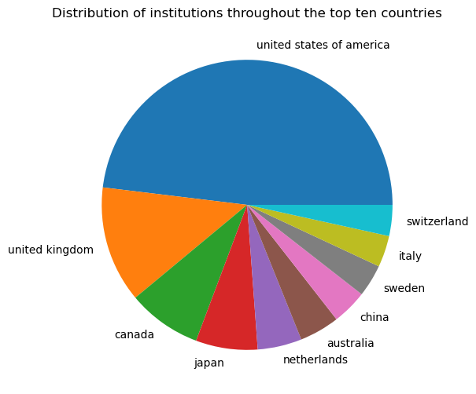

```python
## Visuals

labels = top_10.index

plt.figure(figsize=(10, 6))
plt.pie(top_10, labels=labels)
plt.title('Distribution of institutions throughout the top ten countries')
plt.show()
```

#### Visualizing world ranking distribution based on the df_uni_ranking dataset

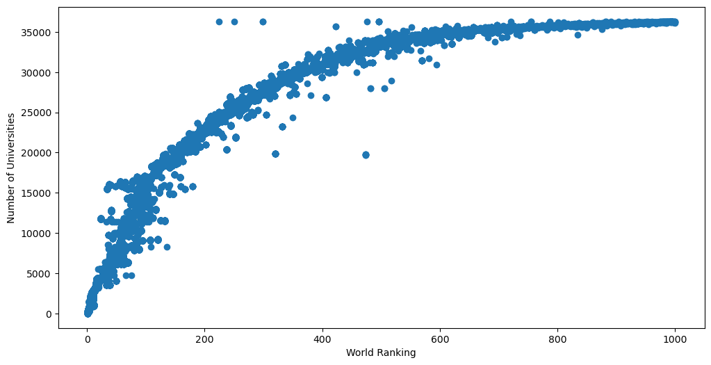

```python
indices = range(len(data['world_rank_cwur']))

plt.figure(figsize=(12, 6))
plt.scatter(data['world_rank_cwur'], indices)
plt.xlabel('World Ranking')
plt.ylabel('Number of Universities')
plt.show()
```

#### Visualizing the relationship between teacher quality and publishing

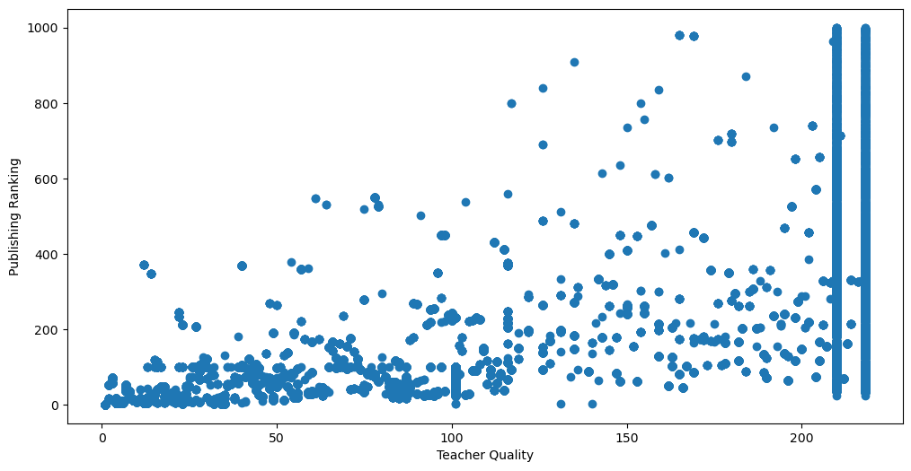

```python
plt.figure(figsize=(12, 6))
plt.scatter(data['quality_of_faculty'], data['publications'])
plt.xlabel('Teacher Quality')
plt.ylabel('Publishing Ranking')
plt.show()
```

- There is a visible trend indicating that universities with higher faculty qualityalso have higher publishing rankings.
- As the quality of faculty rating fluctuates, the publication ranking does so accordingly.

This relationship suggests a possible link between eacher quality and publication rankings. High-quality academics may make a greater contribution to research and publication.

# Step 6: Visualization

#### Visualizing the average education quality by country for the top ten countries

```python
filtered_data = data[data['country_times'].isin(top_10.index.tolist())]

x = filtered_data.groupby('country_times')['quality_of_education'].mean().sort_values()
```

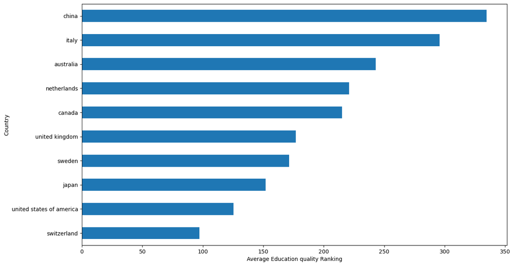

```python
# Plotting the results
plt.figure(figsize=(14, 8))
x.plot(kind='barh')
plt.xlabel('Average Education quality Ranking')
plt.ylabel('Country')

plt.show()
```

A lower average ranking suggests higher quality, as colleges are graded from 1 (highest) to 1000 (worst).

#### Visualizing the trend of the final score for top 5 unis.

```python
top_5 = data.groupby('institution')['score'].mean().sort_values(ascending=False).head(5).index.tolist()

filtered_top_5 = data[data['institution'].isin(top_5)]
```

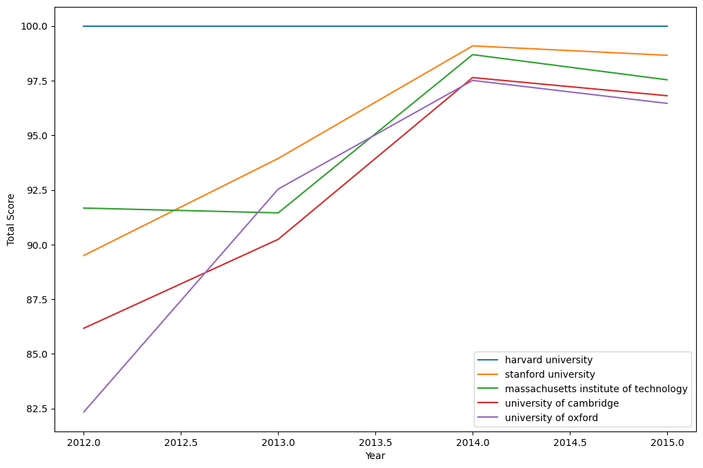

```python
plt.figure(figsize=(12, 8))

for i in top_5:
    subset = filtered_top_5[filtered_top_5['institution'] == i]
    plt.plot(subset['year_cwur'], subset['score'], label=i)

plt.xlabel('Year')
plt.ylabel('Total Score')
plt.legend()
```

Over the years, all of the top five universities have maintained reasonably high scores:

- Harvard University consistently ranks first with the highest overall score.
- Other universities, such as Stanford University and MIT, have good scores as well, but there is a noticeable difference between them and Harvard.

#### Visualizing the distribution of top 10 countries based on alumni employement

```python
alumni_country = data.groupby('country_times')['alumni_employment'].mean().sort_values().head(10)
```

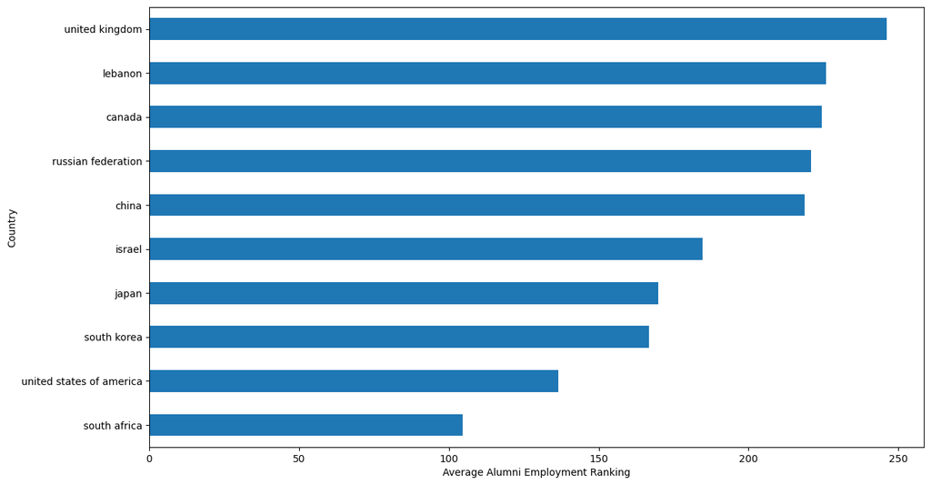

```python
plt.figure(figsize=(14, 8))
alumni_country.plot(kind='barh')
plt.xlabel('Average Alumni Employment Ranking')
plt.ylabel('Country')
plt.show()
```

# Step 7: Documentation

### Objective:

The goal was to analyze the data from several ranking agencies to better understand the elements that influence global university rankings.

### Methodology:

- Data Cleaning: Depending on the relevance of the missing data, missing values were imputed or rows were eliminated.
- Data Merging: The integration was carried out using the university's name and year.
- EDA: We dug into the datasets to look for patterns, distributions, and correlations between measurements.

### Data Integration Strategies:

- Schema Mapping: Identifying matched columns.
- Data Transformation: Maintaining consistentancy.
- Manual Data Reconciliation: Merging datasets.

### Results:

The combined dataset provides a full perspective of university rankings, allowing for cross-comparison and more in-depth analysis.

# Conclusion

By studying top-ranked universities, "Nexa University" strives for global academic excellence. Patrick Chaccour, a data scientist, assisted in navigating large datasets from rating organizations in order to comprehend institution reputation beyond measurements. We discovered that the prestige of colleges, such as Harvard, is influenced by a variety of criteria, including research, faculty excellence, alumni achievement, international diversity... The purpose of "Nexa University" is to take a comprehensive approach that blends diversified skills, research, and real-world preparation. The road to global recognition is difficult, but it is doable with the right strategy.

[figure not shown]

```python
## SUBMISSION FORM

from IPython.display import Image

Image(filename='DI FORM.jpg')
```